# 13 Razdiobe i simulacije

Kristo Palic

2023-01-25

## Popis podržanih razdiobi

- ovo ne uključuje razne razdiobe podržane u dodatnim paketima!

```r
help(Distributions)
```

## Binomna razdioba

$$P(brojIshoda = x) = {n\choose
x}p^x(1-p)^{n-x}$$

- `dbinom(x, size, prob)`
  - vjerojatnost da ćemo pozitivni ishod dobiti `x` puta u `size` ponavljanja ako je vjerojatnost pozitivnog ishoda `prob`
  - `x` može biti vektor (dobivamo vektor vjerojatnosti)
- `pbinom(q, size, prob)`
  - vjerojatnost da ćemo pozitivni ishod dobiti `q` puta **ili manje** u `size` ponavljanja ako je vjerojatnost pozitivnog ishoda `prob`
- `qbinom(p, size, prob)`
  - vrijednost koja se nalazi na `p`-tom kvantilu binomne razdiobe u kojoj imamo `size` ponavljanja i vjerojatnost pozitivnog ishoda `prob`

## Zadatak 13.1 - Binomna razdioba

```r
# koja je vjerojatnost da u 10 bacanja novčića vrijednost "pismo" dobijete točno jednom?
dbinom(1, 10, 0.5)
```

```
## [1] 0.009765625
```

```r
# koja je vjerojatnost da u 20 bacanja novčića broj dobivanja vrijednosti "pismo" bude manji ili jednak 10?
pbinom(10, 20, 0.5)
```

```
## [1] 0.5880985
```

```r
# koja je vrijednost prvog, drugog i trećeg kvartila u bacanju novčića 100 puta?
qbinom(p = c(0.25, 0.5, 0.75), 100, 0.5)
```

```
## [1] 47 50 53
```

```r
# nacrtajte funkciju razdiobe eksperimenta bacanja novčića 100 puta
## NAPUTAK: napravite pomoćni numerički vektor svih mogućih ishoda,
##          konstruirajte podatkovni okvir sa potrebnim podacima a potom nacrtajte razdiobu
##          na grafu odabrane geometrije (točkasta, linijska ili stupčasta)
```

[output not shown]

## Normalna razdioba

$$f(x) = \frac{1}{\sigma\sqrt{2\pi}}
\exp\left(
-\frac{1}{2}\left(\frac{x-\mu}{\sigma}\right)^{\!2}\,\right)$$

- `dnorm(x, mean = 0, sd = 1)`
  - vrijednost funkcije gustoće razdiobe za vrijednost `x` kod normalne razdiobe sa sredinom `mean` i standardnom devijacijom `sd`
- `pnorm(q, mean = 0, sd = 1)`
  - vrijednost kumulativne funkcije razdiobe za vrijednost `x` kod normalne razdiobe sa sredinom `mean` i standardnom devijacijom `sd`
- `qbinom(p, mean = 0, sd = 1)`
  - vrijednost koja se nalazi na `p`-tom kvantilu kod normalne razdiobe sa sredinom `mean` i standardnom devijacijom `sd`

## Zadatak 13.2 - Normalna razdioba

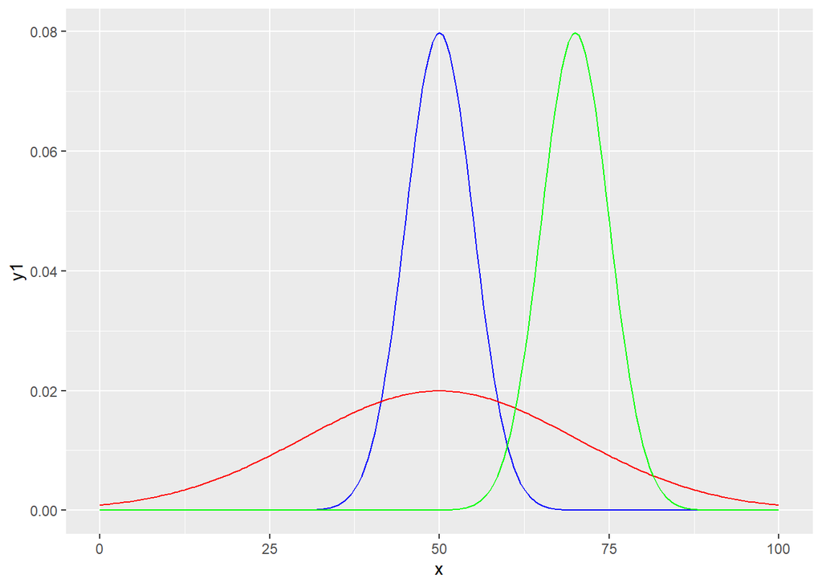

```r
# n istom grafu prikažite funkcije gustoće razdiobe sa sljedećim parametrima
#   - sredina: 50, st.dev: 5   (plava linija)
#   - sredina: 50, st.dev: 20  (crvena linija)
#   - sredina: 70, st.dev: 5   (zelena linija)

x <- seq(0, 100, 0.5)
df <- data.frame(x = x, y1 = dnorm(x, 50, 5), y2 = dnorm(x, 50, 20), y3 = dnorm(x, 70, 5))

ggplot(df, aes(x = x)) + geom_line(aes(y = y1), color = "blue") +
                        geom_line(aes(y = y2), color = "red") +
                        geom_line(aes(y = y3), color = "green")
```

```r
#
## NAPUTAK: koristite trik s "pomoćnim vektorom" iz prethodnog zadatka
##          na isti graf stavite tri geometrije sa redefinicijom y estetike
```

## Generiranje nasumičnih opservacija

Jedna od najčešće korištenih obitelji funkcija vezanih uz razdiobe su funkcije za generiranje nasumičnih opservacija koje odgovaraju zadanoj razdiobi. Kako je već spomenute, sve ove funkcije počinju slovom `r` (od eng. *random*) te nizom znakova koji označavaju naziv razdiobe. Dodatni parametri funkcije ovise o korištenoj razdiobi, a mogu se pronaći u dokumentaciji.

## Zadatak 13.3 - Generiranje nasumičnih opservacija iz odabrane razdiobe

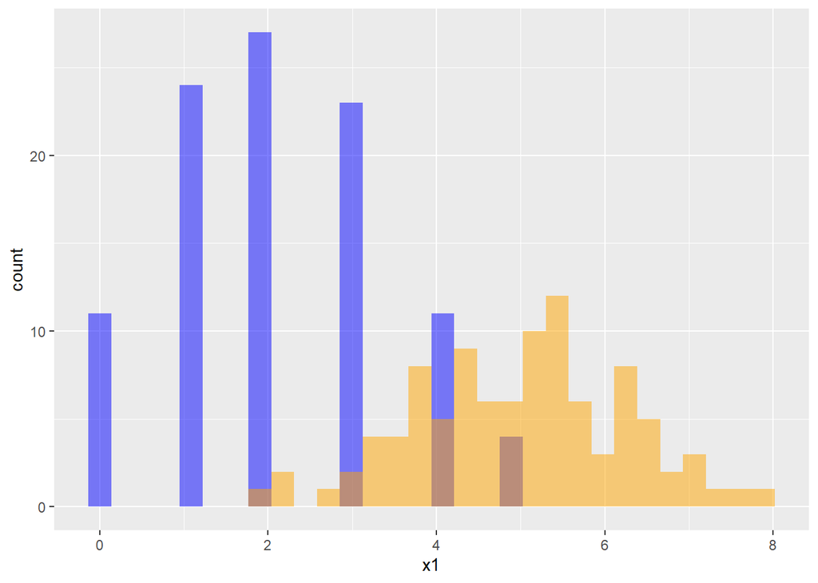

```r
# generirajte 100 opservacija koje odgovaraju broju pozitivnih ishoda
# kod 10 ponavljanja Bernoullijevog eksperimenta sa vjerojatnosti
# pozitivnog ishoda od 0.2
set.seed(1237)
x1 <- rbinom(100, 10, 0.2)
# generirajte 100 opservacija koje odgovaraju normalnoj razdiobi
# sa srednjom vrijednosti 5 i standardnom devijacijom 1.265
x2 <- rnorm(100, 5, 1.265)
# na istom grafu nacrtajte histograme oba skupa opservacija
# (sami odaberite prikladnu širinu ladice)

data.frame(x1 = x1, x2 = x2) %>%
  ggplot(aes(x = x1)) + geom_histogram(fill = "blue", alpha = 0.5, bins = 30) +
  geom_histogram(aes (x = x2), fill = "orange", alpha = 0.5, bins = 30)
```

## Funkcija `geom_density`

Proces analize podataka često uključuje provjeru izgleda razdiobe određene varijable (mjere). Jedan od načina kako ovo izvesti jest uz pomoć histograma, kao u prethodnom zadatku. Drugi način jest koristiti funkciju `geom_density` paketa `ggplot2` koja će uz pomoć posebnog algoritma pokušati “pogoditi” funkciju razdiobe te ju vizualizirati na grafu.

## Zadatak 13.4 - Funkcija `geom_density`

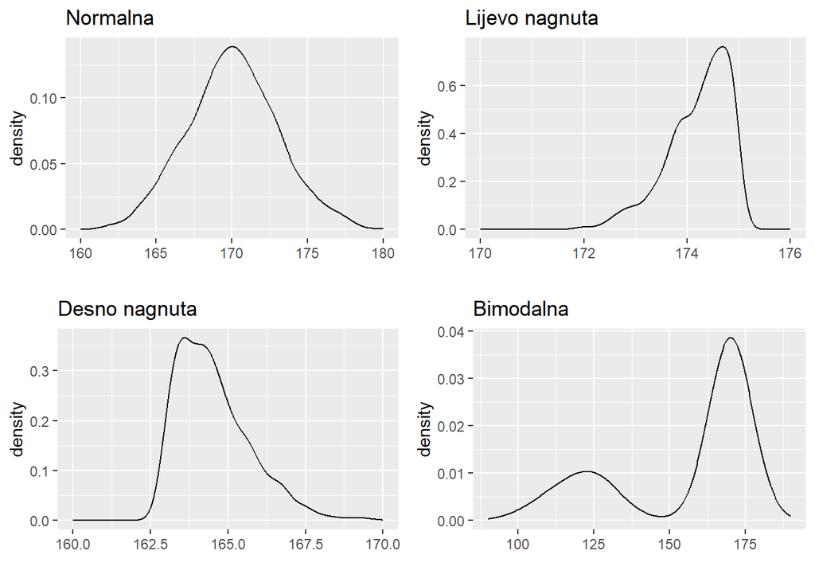

```r
# učitajte podatke iz datoteke "podaci.csv" i prikažite izgled
# procjenjene funkcije razdiobe za svaki od stupaca
# komentirajte izgled tj. prirodu prikazanih razdiobi
data <- read.csv("./podaci.txt")

g1 <- ggplot(data, aes(x1)) + geom_density() + labs(x = "", title = "Normalna") + xlim(c(160, 180))
g2 <- ggplot(data, aes(x2)) + geom_density() + labs(x = "", title = "Lijevo nagnuta") + xlim(c(170, 176))
g3 <- ggplot(data, aes(x3))+ geom_density() + labs(x = "", title = "Desno nagnuta") + xlim(c(160, 170))
g4 <- ggplot(data, aes(x4)) + geom_density() + labs(x = "", title = "Bimodalna") + xlim(c(90, 190))

grid.arrange(g1, g2, g3, g4, nrow = 2, ncol = 2)
```

## QQ graf (*quantile-quantile* graf)

Za provjeru normalnosti razdiobe odabrane varijable često se koristi i tzv. “QQ graf” (od engl. *quantile-quantile*). Ovaj graf radi na sljedeći način: opservacije se poredaju na jednu os prema svojoj vrijednosti dok na drugu os stavljamo njihovu očekivanu Z-vrijednost (engl. *Z-score*) koji predstavlja “udaljenost od sredine po broju standardnih devijacija”). Kod normalne razdiobe QQ graf leži na dijagonali grafa, dok se odstupanje od normalne razdiobe očituje u “izvijenosti” grafa tj. odstupanju od “pravca normalnosti”.

Funkcija geometrije `geom_qq` uz definiranu estetiku `sample` nam omogućuje jednostavno stvaranje QQ grafa odabrane varijable.

## Zadatak 13.5 - Funkcija `geom_qq`

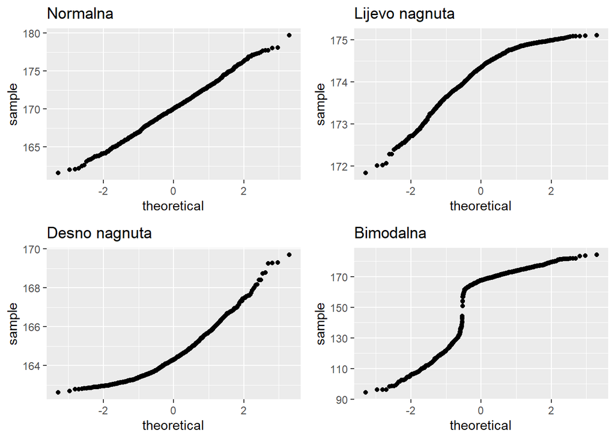

```r
# nacrtajte QQ grafove varijabli iz prethodnog zadatka
g1 <- ggplot(data, aes(sample = x1)) + geom_qq() + labs(title = "Normalna")
g2 <- ggplot(data, aes(sample = x2)) + geom_qq() + labs(title = "Lijevo nagnuta")
g3 <- ggplot(data, aes(sample = x3)) + geom_qq() + labs(title = "Desno nagnuta")
g4 <- ggplot(data, aes(sample = x4)) + geom_qq() + labs(title = "Bimodalna")

grid.arrange(g1, g2, g3, g4, nrow = 2, ncol = 2)
```

## Zadatak 13.6 - Funkcija `sample`

```r
set.seed(1234)
# napišite funkciju `baciNovcic(n)` koja će vratiti vektor duljine `n` sa nasumično
# odabranim vrijednostima 0 (pismo) i 1 (glava)
# bacite novčić 10, 100, 1000 i 1,000,000 puta te ispišite postotak slučajeva kada je ispala "glava"
baciNovcic <- function(n) {
  sample(c(0,1), n, replace = TRUE)
}

mean(baciNovcic(10))
```

```
## [1] 0.6
```

```r
mean(baciNovcic(100))
```

```
## [1] 0.55
```

```r
mean(baciNovcic(1000))
```

```
## [1] 0.473
```

```r
mean(baciNovcic(1000000))
```

```
## [1] 0.500244
```

## Funkcija `replicate`

Na sličan način možemo provjeriti kolika je vjerojatnost pojedinog zbroja kod bacanja dvije kockice. Ovdje nam nije dosta jedan poziv funkcije `sample`, već trebamo zbroj dva poziva te funkcije kojeg ćemo računati velikih broj puta. Jedno od mogućih rješenja kako ovo isprogramirati jest uz pomoć petlje, no budući da znamo kako je u jeziku *R* poželjno izbjeći petlje ukoliko je to moguće, preporučljivije je koristiti funkciju `replicate`:

```r
replicate(n, expr, simplify = "array")
```

Ova funkcija uzima izraz `expr` i ponavlja ga `n` puta, pri čemu slaže međurezultate u prikladnu strukturu (ukoliko pogledamo dokumentaciju, uvidjet ćemo da je ova funkcija zapravo izvedenica funkcije `sapply`).

## Zadatak 13.7 - Funkcija `replicate`

```r
set.seed(1234)
# napravite funkciju `baci2kockice(n)` koja vraća vektor od n elemenata
# gdje je svaki element zbroj rezultata jednog bacanja dvije kockice
baci2kockice <- function(n) {
  replicate(n, sample(1:6, 1) + sample(1:6, 1))
}

table(baci2kockice(100)) / 100
```

```
##
##    2    3    4    5    6    7    8    9   10   11   12
## 0.02 0.04 0.08 0.09 0.15 0.17 0.17 0.12 0.05 0.07 0.04
```

```r
table(baci2kockice(1000)) / 1000
```

```
##
##     2     3     4     5     6     7     8     9    10    11    12
## 0.023 0.051 0.082 0.119 0.130 0.152 0.132 0.132 0.086 0.056 0.037
```

```r
#round(table(baci2kockice(1000000)) / 1000000, 3)
# ispišite vjerojatnosti svakog mogućeg zbroja za 100, 1000 i 1,000,000 bacanja kockice
```

## Zadatak 13.8 - Matrični rezultat funkcije `replicate`

```r
set.seed(1234)
# 1000 puta ponovite simulaciju bacanja kockice 20 puta
# rezultate simulacije pohranite u matricu gdje će retci biti
# zapis 20 ishoda pojedinog bacanja
replicate(1000, sample(1:6, 20, T)) %>% t -> rez

# ispišite prva 3 redaka dobivene matrice
rez[1:3, ]
```

```
##      [,1] [,2] [,3] [,4] [,5] [,6] [,7] [,8] [,9] [,10] [,11] [,12] [,13] [,14]
## [1,]    4    2    6    5    4    1    5    6    4     2     6     2     6     6
## [2,]    5    4    3    4    5    2    5    2    6     3     4     4     3     1
## [3,]    5    6    1    6    3    6    1    5    1     1     2     1     3     2
##      [,15] [,16] [,17] [,18] [,19] [,20]
## [1,]     4     6     6     6     4     4
## [2,]     3     6     4     2     3     2
## [3,]     6     3     1     3     6     1
```